# 11 Manuscript figures

## 11.5 Figure 2

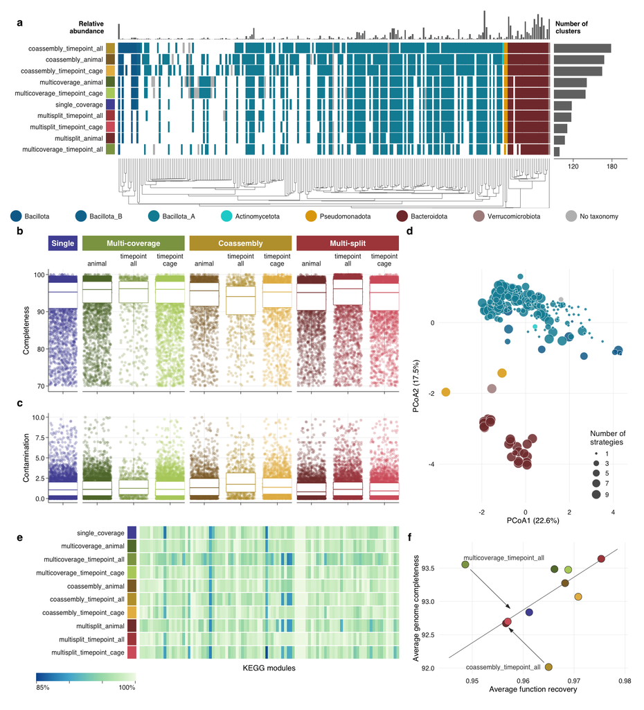

```r
fig2_h <- 238                                                   # mm
fig2_layout <- "
AA
BD
CD
EF
"
fig2 <- wrap_plots(A = wrap_elements(full = fig2_a), B = fig2_b, C = fig2_c, D = fig2_d,
                   E = wrap_elements(full = fig2_e), `F` = fig2_f, design = fig2_layout) +
  plot_layout(widths = c(130, 70), heights = c(81, 52, 38, 56)) +
  plot_annotation(tag_levels = "a", theme = theme(plot.margin = margin(margin_mm, margin_mm, margin_mm, margin_mm, "mm"),
                                                  panel.spacing = unit(2, "mm"))) &
  tag_theme
fig2
```

## 11.6 Figure 3

Panel a keeps the chart of the original (jittered points and boxplot per strategy, one facet per Hill-number metric). Panel b shows the lower-triangle matrix of Procrustes dissimilarity between the NMDS ordinations of the strategies, computed on the aligned samples (chapter 6). **Dissimilarity is the Procrustes sum of squares, `ss = 1 - r^2`, where `r` is the Procrustes correlation stored in `procrustes_mat` (`protest()$t0`).** The permutation p-values of all pairwise tests are 0.001 (999 permutations, the minimum attainable), as checked below. Panels a and b are stacked in one patchwork so that their facet columns are aligned exactly.

```r
alpha_labels <- c(richness = "Richness", neutral = "Neutral diversity", phylo = "Phylogenetic diversity")

alpha_long <- alpha_div %>%
  pivot_longer(!c(strategy, sample), names_to = "metric", values_to = "value") %>%
  mutate(metric = factor(alpha_labels[metric], levels = alpha_labels),
         strategy = factor(strategy, levels = rev(strategies)))
alpha_box <- alpha_long %>% group_by(strategy, metric) %>% reframe(box_stats(value))

set.seed(1)
fig3_a <- ggplot(alpha_long, aes(y = strategy, colour = strategy)) +
  ggrastr::geom_point_rast(aes(x = value), position = position_jitter(width = 0, height = 0.27), shape = 16,
                           size = dsize(0.8), alpha = 0.35, raster.dpi = 300) +
  geom_segment(data = alpha_box, aes(yend = strategy, x = upper, xend = ymax), linewidth = lw(0.25)) +
  geom_segment(data = alpha_box, aes(yend = strategy, x = lower, xend = ymin), linewidth = lw(0.25)) +
  geom_crossbar(data = alpha_box, aes(x = middle, xmin = lower, xmax = upper), orientation = "y", fill = "white", alpha = 0.7,
                width = 0.6, linewidth = lw(0.4), fatten = 1.6) +
  scale_colour_manual(values = strategy_colors) +
  facet_wrap(~metric, scales = "free_x", nrow = 1) +
  theme_fig() +
  theme(legend.position = "none", panel.spacing.x = unit(6, "mm"),
        axis.line.x = element_line(colour = col_text, linewidth = lw(0.4)),
        axis.ticks.y = element_blank(), axis.ticks.x = element_line(colour = col_text, linewidth = lw(0.4)),
        axis.ticks.length.x = unit(0.8, "mm"), axis.title.x = element_text(size = sz$axis, margin = margin(t = 1.5, unit = "mm")),
        strip.text = element_text(size = sz$strip, margin = margin(0, 0, 1.5, 0, "mm"))) +
  labs(y = "Strategy", x = "Effective number of MAGs")
```

```r
procrustes_labels <- c(q0n = "Richness", q1n = "Neutral diversity", q1p = "Phylogenetic diversity")
stopifnot(all(sapply(procrustes_p, function(x) all(x[upper.tri(x)] == 0.001))))   # all permutation p = 0.001

# As in the original, strategies keep alphabetical (factor) order: columns coassembly_animal ... single_coverage left to right,
# rows single_coverage (top) ... coassembly_animal (bottom); the lower triangle (including the diagonal) is shown
tri_levels <- sort(strategies)

procrustes_long <- purrr::map_dfr(names(procrustes_mat), function(m) {
  as.data.frame(as.table(procrustes_mat[[m]])) %>%
    rename(v1 = Var1, v2 = Var2, correlation = Freq) %>%
    mutate(metric = procrustes_labels[[m]])
}) %>%
  mutate(dissimilarity = 1 - correlation^2,              # Procrustes sum of squares
         i1 = match(v1, tri_levels), i2 = match(v2, tri_levels),
         metric = factor(metric, levels = procrustes_labels)) %>%
  filter(i1 <= i2)

diag_df <- procrustes_long %>% filter(i1 == i2) %>% select(metric, strategy = v1, i1, i2)
off_df <- procrustes_long %>% filter(i1 < i2)

# Sequential yellow (low dissimilarity) -> dark blue (high), ColorBrewer YlGnBu, shared 0-1 scale for the three matrices
dis_scale <- function() scale_fill_distiller(palette = "YlGnBu", direction = 1, limits = c(0, 1), guide = "none")

# Colour bar drawn in the data coordinates of the last matrix, in its empty lower-right corner (aligned with the tiles)
lg_x <- c(6.85, 10.45); lg_n <- 60
lg_bar <- tibble(metric = factor(procrustes_labels[3], levels = procrustes_labels),
                 x = seq(lg_x[1], lg_x[2], length.out = lg_n), v = seq(0, 1, length.out = lg_n))
lg_ticks <- tibble(metric = factor(procrustes_labels[3], levels = procrustes_labels), v = c(0, 0.25, 0.5, 0.75, 1),
                   lab = c("0", "0.25", "0.5", "0.75", "1")) %>%
  mutate(x = lg_x[1] + v * diff(lg_x), hj = c(0, 0.5, 0.5, 0.5, 1))

fig3_b <- ggplot() +
  geom_tile(data = off_df, aes(x = i1, y = i2, fill = dissimilarity), colour = "white", linewidth = lw(0.2)) +
  geom_tile(data = lg_bar, aes(x = x, y = 1.55, fill = v), width = diff(lg_x) / lg_n * 1.5, height = 0.5) +
  dis_scale() +
  geom_segment(data = lg_ticks, aes(x = x, xend = x, y = 1.25, yend = 1.0), linewidth = lw(0.4), colour = col_text) +
  geom_text(data = lg_ticks, aes(x = x, y = 0.9, label = lab, hjust = hj), vjust = 1, size = pt(sz$legend), family = fig_font, colour = col_text) +
  geom_text(data = lg_ticks[1, ], aes(x = lg_x[1], y = 2.35, label = "Dissimilarity"), hjust = 0, vjust = 0.5, size = pt(sz$legend_title),
            family = fig_font, colour = "black") +
  new_scale_fill() +
  geom_tile(data = diag_df, aes(x = i1, y = i2, fill = strategy), colour = "white", linewidth = lw(0.4)) +
  scale_fill_manual(values = strategy_colors, guide = "none") +
  geom_text(data = diag_df, aes(x = i1, y = i2 - 0.62, label = strategy), angle = 90, hjust = 1, vjust = 0.5,
            size = pt(sz$row), colour = col_text, family = fig_font) +
  scale_x_continuous(breaks = NULL, expand = c(0, 0), limits = c(0.5, 10.5)) +
  scale_y_continuous(breaks = seq_along(tri_levels), labels = tri_levels, expand = c(0, 0), limits = c(-4.4, 10.5)) +
  facet_wrap(~metric, nrow = 1) +
  theme_void_fig() +
  theme(strip.text = element_blank(),
        axis.text.y = element_text(colour = col_text, size = sz$row, hjust = 1, margin = margin(r = 1.5, unit = "mm")),
        # hjust centres the title on the heatmap rows, not on rows + rotated labels: rows are centred at 66.5% of the panel height and
        # hjust also shifts the text by (0.5 - hjust) x its length, hence 0.689 instead of 0.665 (checked visually)
        axis.title.y = element_text(size = sz$axis, angle = 90, hjust = 0.689, margin = margin(r = 2, unit = "mm")),
        panel.spacing.x = unit(6, "mm")) +
  labs(y = "Strategy")
```

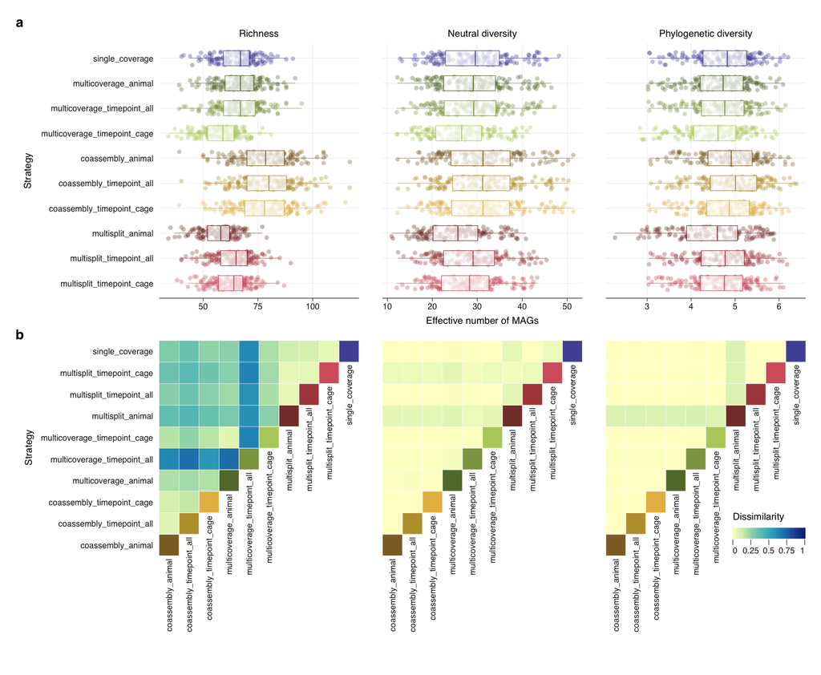

```r
fig3_h <- 150                                                   # mm
fig3 <- fig3_a / fig3_b +
  plot_layout(heights = c(62, 78)) +
  plot_annotation(tag_levels = "a", theme = theme(plot.margin = margin(margin_mm, margin_mm, margin_mm, margin_mm, "mm"),
                                                  panel.spacing = unit(2, "mm"))) &
  tag_theme
fig3
```

## 11.7 Figure 4

Panel a is the community turnover (Sørensen-type overlap-complement, `hilldiss(metric = "C", q = 0)`, richness, the metric tested in chapter 7) between the three sampling points (OP, HR, CR) of each animal, females versus males (15 and 15 animals), for each processing strategy. The asterisks come from the Kruskal-Wallis test of turnover by sex within each strategy (alpha = 0.05, no correction for multiple testing; `ns` otherwise). Panel b shows, for every strategy and KEGG module, the outcome of the hot versus cold comparison of community-weighted module fullness (chapter 8: `lmer(value ~ treatment + (1 | animal))`, Bonferroni correction within strategy, modules with a mean community fullness above 0.3), read from `results/casestudy2_kegg_comparison.Rdata`. Strategies are ordered by the hierarchical clustering of the Euclidean distances between their estimate vectors (as in chapter 8) and modules by identifier.

```r
library(hilldiv2)

sub_names4 <- setNames(c("", rep(c("animal", "timepoint_all", "timepoint_cage"), 3)), quality_order)

# Turnover between the sampling points of every animal, per strategy (richness, q = 0)
sample_list <- bin_counts %>% select(sample) %>% unique() %>%
  mutate(animal = substr(sample, 1, 5), timepoint = substr(sample, 6, 7)) %>%
  filter(timepoint %in% c("OP", "HR", "CR")) %>%
  group_by(animal) %>% group_split() %>% set_names(map_chr(., ~ .x$animal[1]))

turnover <- map_dfr(strategies, function(st) {
  map_dfr(names(sample_list), function(an) {
    counts <- bin_counts_norm_filt %>%
      filter(overall_strategy == st, sample %in% sample_list[[an]]$sample) %>%
      select(secondary_cluster, sample, read_count) %>%
      pivot_wider(names_from = "sample", values_from = "read_count", values_fn = sum) %>%
      mutate(across(where(is.double), ~ . / sum(.))) %>%
      column_to_rownames("secondary_cluster")
    tibble(animal = an, strategy = st, turnover = suppressMessages(hilldiss(data = counts, metric = "C", q = 0)))
  })
}) %>%
  mutate(sex = substr(animal, 4, 4), strategy = factor(strategy, levels = quality_order),
         group = factor(case_when(grepl("^single", strategy) ~ "Single", grepl("^multicoverage", strategy) ~ "Multi-coverage",
                                  grepl("^coassembly", strategy) ~ "Coassembly", TRUE ~ "Multi-split"), levels = group_levels),
         sub = factor(sub_names4[as.character(strategy)], levels = unique(sub_names4)))

# Kruskal-Wallis test of turnover by sex within each strategy (alpha = 0.05, no multiple-testing correction)
turnover_tests <- turnover %>% group_by(strategy, group, sub) %>%
  summarise(p_value = kruskal.test(turnover ~ sex)$p.value, n_F = sum(sex == "F"), n_M = sum(sex == "M"), .groups = "drop") %>%
  mutate(significant = p_value < 0.05)

turnover_box <- turnover %>% group_by(strategy, group, sub, sex) %>% reframe(box_stats(turnover))
y_top <- max(turnover_box$ymax)
bracket <- turnover_tests %>% mutate(y = y_top + 0.012, label = if_else(significant, "*", "ns"),
                                     col = if_else(significant, "black", "grey55"))

fig4_a <- ggplot(turnover_box, aes(x = sex, colour = strategy, fill = strategy)) +
  geom_segment(aes(xend = sex, y = upper, yend = ymax), linewidth = lw(0.3), lineend = "butt") +
  geom_segment(aes(xend = sex, y = lower, yend = ymin), linewidth = lw(0.3), lineend = "butt") +
  geom_crossbar(aes(y = middle, ymin = lower, ymax = upper), width = 0.7, linewidth = lw(0.4), fatten = 1.8) +
  geom_segment(data = bracket, aes(x = 1, xend = 2, y = y, yend = y, colour = NULL, fill = NULL), colour = bracket$col, linewidth = lw(0.4)) +
  geom_segment(data = bracket, aes(x = 1, xend = 1, y = y, yend = y - 0.004, colour = NULL, fill = NULL), colour = bracket$col, linewidth = lw(0.4)) +
  geom_segment(data = bracket, aes(x = 2, xend = 2, y = y, yend = y - 0.004, colour = NULL, fill = NULL), colour = bracket$col, linewidth = lw(0.4)) +
  geom_text(data = bracket, aes(x = 1.5, y = y + 0.002, label = label, colour = NULL, fill = NULL), colour = bracket$col,
            vjust = if_else(bracket$significant, 0.15, 0), size = pt(if_else(bracket$significant, 8, sz$tick)), family = fig_font) +
  scale_colour_manual(values = strategy_colors) +
  scale_fill_manual(values = scales::alpha(strategy_colors, 0.3)) +
  scale_y_continuous(breaks = seq(0.10, 0.25, 0.05), labels = c("0.10", "0.15", "0.20", "0.25")) +
  coord_cartesian(ylim = c(min(turnover_box$ymin) - 0.004, y_top + 0.03)) +
  ggh4x::facet_nested(. ~ group + sub, scales = "fixed",
                      strip = ggh4x::strip_nested(
                        background_x = c(lapply(unname(group_colors), function(f) element_rect(fill = f, colour = NA)),
                                         rep(list(element_blank()), 10)),
                        text_x = c(rep(list(element_text(colour = "white", size = sz$strip, face = "bold")), 4),
                                   rep(list(element_text(colour = "black", size = sz$tick)), 10)),
                        clip = "off")) +
  labs(x = "Sex", y = "Community turnover") +
  theme_fig() +
  theme(legend.position = "none", panel.spacing.x = unit(1.2, "mm"),
        panel.border = element_rect(colour = "grey70", fill = NA, linewidth = lw(0.4)),
        axis.ticks = element_line(colour = "grey50", linewidth = lw(0.4)), axis.ticks.length = unit(0.8, "mm"),
        strip.text.x = element_text(margin = margin(0.8, 0, 0.8, 0, "mm")), ggh4x.facet.nestline = element_blank())
```

```r
# Outcome per strategy and module: blue = significantly higher under cold, red = significantly higher under hot (Bonferroni p < 0.05)
trend_cols <- c(cold = "#78bacf", hot = "#e0766e", neutral = "#f4f4f4")
module_trend <- all_p_values %>%
  mutate(trend = case_when(p_value_adj < 0.05 & estimate > 0 ~ "hot", p_value_adj < 0.05 & estimate < 0 ~ "cold", TRUE ~ "neutral"))
modules_b <- sort(unique(module_trend$trait))
n_mod <- length(modules_b); n_str <- length(strategies)

# Strategy dendrogram: Euclidean distance between the vectors of estimates, hierarchical clustering (as in chapter 8)
est_matrix <- all_p_values %>% select(-p_value_adj) %>% pivot_wider(names_from = "trait", values_from = "estimate") %>%
  column_to_rownames("strategy")
dend <- ape::as.phylo(hclust(dist(est_matrix)))
dend_data <- ggtree::ggtree(dend)$data
row_y <- dend_data %>% filter(isTip) %>% select(strategy = label, y)             # one row per strategy; y = row position
dend_edges <- dend_data %>% filter(parent != node) %>%
  left_join(dend_data %>% select(node, px = x), by = c("parent" = "node"))
dend_vert <- dend_edges %>% group_by(parent, px) %>% summarise(y0 = min(y), y1 = max(y), .groups = "drop")
dend_w <- max(dend_data$x)

p_dend <- ggplot() +
  geom_segment(data = dend_edges, aes(x = px, xend = x, y = y, yend = y), linewidth = lw(0.25), colour = "grey20", lineend = "butt") +
  geom_segment(data = dend_vert, aes(x = px, xend = px, y = y0, yend = y1), linewidth = lw(0.25), colour = "grey20", lineend = "butt") +
  scale_x_continuous(expand = c(0, 0)) + scale_y_continuous(expand = c(0, 0)) +
  coord_cartesian(xlim = c(0, dend_w), ylim = c(0.5, n_str + 0.5), expand = FALSE) + theme_void_fig()

p_strip4 <- ggplot(row_y, aes(fill = strategy)) +
  geom_tile(aes(x = 1, y = y), width = 1, height = 0.94) +
  scale_fill_manual(values = strategy_colors) +
  scale_x_continuous(limits = c(0.5, 0.5 + 4 / 3), expand = c(0, 0)) + scale_y_continuous(limits = c(0.5, n_str + 0.5), expand = c(0, 0)) +
  theme_void_fig() + theme(legend.position = "none")

p_lab4 <- ggplot(row_y) +
  geom_text(aes(x = 0.02, y = y, label = strategy), hjust = 0, size = pt(sz$row), family = fig_font, colour = col_text) +
  scale_x_continuous(limits = c(0, 1), expand = c(0, 0)) + scale_y_continuous(limits = c(0.5, n_str + 0.5), expand = c(0, 0)) +
  coord_cartesian(clip = "off") + theme_void_fig()

heat4 <- module_trend %>% left_join(row_y, by = "strategy") %>% mutate(x = match(trait, modules_b))
p_heat4 <- ggplot(heat4, aes(x = x, y = y, fill = trend)) +
  geom_tile(width = 1, height = 0.94) +
  scale_fill_manual(values = trend_cols) +
  coord_cartesian(xlim = c(0.5, n_mod + 0.5), ylim = c(0.5, n_str + 0.5), expand = FALSE) +
  theme_void_fig() + theme(legend.position = "none")

# Highlighted modules (arrows above the heatmap) and module identifiers below it
hl <- tibble(module = c("M00082", "M00093"), label = c("Fatty acid biosynthesis", "Phosphatidylethanolamine (PE) biosynthesis"),
             col = c("#1f5f73", "#8f2d2d"), x = match(module, modules_b), side = c("left", "right"))
stopifnot(!anyNA(hl$x))
hl_head <- arrow(length = unit(1.4, "mm"), angle = 20, type = "closed")
p_ann4 <- ggplot() +
  geom_segment(data = hl %>% mutate(x0 = if_else(side == "left", x - 4, x + 4)), aes(x = x0, xend = x, y = 0.55, yend = 0.55),
               linewidth = lw(0.5), colour = "black", lineend = "butt") +
  geom_segment(data = hl, aes(x = x, xend = x, y = 0.55, yend = 0.04), linewidth = lw(0.5), colour = "black", arrow = hl_head) +
  geom_text(data = hl %>% mutate(xt = if_else(side == "left", x - 4.8, x + 4.8)), aes(x = xt, y = 0.55, label = label, colour = col,
            hjust = if_else(side == "left", 1, 0)), size = pt(sz$tick), family = fig_font) +
  scale_colour_identity() +
  coord_cartesian(xlim = c(0.5, n_mod + 0.5), ylim = c(0, 1), expand = FALSE) + theme_void_fig()

# One label per two modules (6 pt identifiers need about 2 mm per column, a column is about 1.5 mm); highlighted modules are always labelled
lab_idx <- sort(unique(c(seq(1, n_mod, 2), hl$x)))
lab_idx <- lab_idx[!(lab_idx %in% (c(hl$x - 1, hl$x + 1)))]
modlab <- tibble(x = lab_idx, module = modules_b[lab_idx], bold = module %in% hl$module)
p_mod4 <- ggplot(modlab) +
  geom_segment(aes(x = x, xend = x, y = 1, yend = 0.93), linewidth = lw(0.25), colour = "grey50") +
  geom_text(aes(x = x, y = 0.88, label = module, fontface = if_else(bold, "bold", "plain")), angle = 90, hjust = 1, vjust = 0.5,
            size = pt(sz$tick), family = fig_font, colour = col_text) +
  coord_cartesian(xlim = c(0.5, n_mod + 0.5), ylim = c(0, 1), expand = FALSE) + theme_void_fig()

fig4_b <- wrap_plots(spc(), spc(), spc(), p_ann4,
                     p_dend, p_strip4, p_lab4, p_heat4,
                     spc(), spc(), spc(), p_mod4, design = "ABCD\nEFGH\nIJKL") +
  plot_layout(widths = unit(c(15, 4, 33, 1), c("mm", "mm", "mm", "null")), heights = c(7, 60, 11)) +
  plot_annotation(theme = theme(panel.spacing = unit(0, "mm"), plot.margin = margin(0, 1.9, 0, 0, "mm")))   # heatmap ends where the panels of a end
```

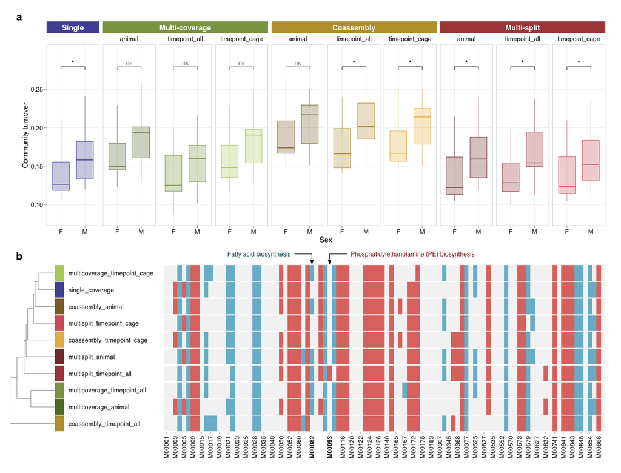

```r
fig4_h <- 158                                                   # mm
fig4 <- fig4_a / wrap_elements(full = fig4_b) +
  plot_layout(heights = c(72, 78)) +
  plot_annotation(tag_levels = "a", theme = theme(plot.margin = margin(margin_mm, margin_mm, margin_mm, margin_mm, "mm"),
                                                  panel.spacing = unit(2, "mm"))) &
  tag_theme
fig4
```

## 11.8 Export

Journal-style export: 210 mm (A4 width) wide, vector PDF (Cairo, fonts embedded), 300 dpi PNG and SVG (text kept as text). The dense jittered point clouds of panels 2b, 2c and 3a are raster layers inside the vector files.

```r
dir.create("figures", showWarnings = FALSE)

save_fig <- function(plot, name, width_mm, height_mm) {
  stopifnot(name %in% "Figure4_v1")   # never overwrite the existing figure files (Figures 2 and 3 are final as Figure2_v6 / Figure3_v5)
  ggsave(paste0("figures/", name, ".pdf"), plot, width = width_mm, height = height_mm, units = "mm", device = cairo_pdf)
  ggsave(paste0("figures/", name, ".png"), plot, width = width_mm, height = height_mm, units = "mm", dpi = 300, bg = "white")
  if (requireNamespace("svglite", quietly = TRUE)) {
    ggsave(paste0("figures/", name, ".svg"), plot, width = width_mm, height = height_mm, units = "mm", device = svglite::svglite)
  }
}

# Figures 2 and 3 are already written (Figure2_v6, Figure3_v5); to regenerate them, save under a new name:
# save_fig(fig2, "Figure2_v7", fig_w, fig2_h); save_fig(fig3, "Figure3_v6", fig_w, fig3_h)
save_fig(fig4, "Figure4_v1", fig_w, fig4_h)
```

## 11.9 Values quoted in the legends

```r
tibble(
  quantity = c("Clusters", "MAGs", "Completeness mean (%)", "Completeness SD", "Contamination mean (%)", "Contamination SD",
               "Clusters in coassembly_timepoint_all", "Clusters recovered by all 10 strategies",
               "PCoA axis 1 (% variance)", "PCoA axis 2 (% variance)", "PCoA axes with negative eigenvalues",
               "Correlation function recovery vs completeness (r, 10 strategies)", "Correlation excluding the two arrowed strategies (r, 8 strategies)"),
  value = c(n_distinct(cluster_presence$secondary_cluster), nrow(bin_metadata),
            mean(bin_metadata$completeness), sd(bin_metadata$completeness),
            mean(bin_metadata$contamination), sd(bin_metadata$contamination),
            strategy_n_clusters$n[strategy_n_clusters$overall_strategy == "coassembly_timepoint_all"],
            length(all_strategy_clusters), pcoa_var[1], pcoa_var[2], pcoa_negative_eig, unname(r_fc$estimate), r_ref)
) %>%
  mutate(value = round(value, 2)) %>%
  tt()
```

| quantity | value |
| --- | --- |
| Clusters | 235.00 |
| MAGs | 25983.00 |
| Completeness mean (%) | 93.14 |
| Completeness SD | 6.92 |
| Contamination mean (%) | 1.48 |
| Contamination SD | 1.47 |
| Clusters in coassembly_timepoint_all | 179.00 |
| Clusters recovered by all 10 strategies | 77.00 |
| PCoA axis 1 (% variance) | 22.60 |
| PCoA axis 2 (% variance) | 17.52 |
| PCoA axes with negative eigenvalues | 0.00 |
| Correlation function recovery vs completeness (r, 10 strategies) | 0.21 |
| Correlation excluding the two arrowed strategies (r, 8 strategies) | 0.87 |

Module left out of the heatmap of Figure 2e (it is kept in all statistics): its ID, the number of the clusters recovered by all strategies that carry it, and its mean recovery per strategy.

```r
tibble(module = excluded_module, clusters_carrying_it = excluded_module_clusters,
       colour_scale_min_panel_e = kegg_lo, next_lowest_module_mean = module_mean$mean_recovery[2]) %>% tt()
```

| module | clusters_carrying_it | colour_scale_min_panel_e | next_lowest_module_mean |
| --- | --- | --- | --- |
| M00569 | 61 | 0.85 | 0.902999 |

```r
excluded_module_values %>% mutate(recovery = round(recovery, 3)) %>% tt()
```

| overall_strategy | recovery |
| --- | --- |
| single_coverage | 0.738 |
| multicoverage_animal | 0.705 |
| multicoverage_timepoint_all | 0.758 |
| multicoverage_timepoint_cage | 0.779 |
| coassembly_animal | 0.672 |
| coassembly_timepoint_all | 0.783 |
| coassembly_timepoint_cage | 0.730 |
| multisplit_animal | 0.689 |
| multisplit_timepoint_all | 0.803 |
| multisplit_timepoint_cage | 0.615 |

Values quoted in the legend of Figure 4 (panel a: Kruskal-Wallis test of turnover by sex within each strategy, 15 females and 15 males, no correction for multiple testing; panel b: hot versus cold comparison, Bonferroni correction within strategy over the modules tested).

```r
turnover_tests %>% transmute(strategy, n_females = n_F, n_males = n_M, kruskal_wallis_p = signif(p_value, 3), significant) %>% tt()
```

| strategy | n_females | n_males | kruskal_wallis_p | significant |
| --- | --- | --- | --- | --- |
| single_coverage | 15 | 15 | 0.0442 | TRUE |
| multicoverage_animal | 15 | 15 | 0.1650 | FALSE |
| multicoverage_timepoint_all | 15 | 15 | 0.2290 | FALSE |
| multicoverage_timepoint_cage | 15 | 15 | 0.0744 | FALSE |
| coassembly_animal | 15 | 15 | 0.1200 | FALSE |
| coassembly_timepoint_all | 15 | 15 | 0.0488 | TRUE |
| coassembly_timepoint_cage | 15 | 15 | 0.0464 | TRUE |
| multisplit_animal | 15 | 15 | 0.0362 | TRUE |
| multisplit_timepoint_all | 15 | 15 | 0.0362 | TRUE |
| multisplit_timepoint_cage | 15 | 15 | 0.0265 | TRUE |

```r
module_summary <- module_trend %>% group_by(trait) %>% summarise(n_significant = sum(trend != "neutral"), .groups = "drop")
tibble(
  quantity = c("Strategies", "Modules shown in panel b (mean fullness > 0.3, per strategy)", "Tests per strategy (Bonferroni family)",
               "Strategies significant in panel a (richness, p < 0.05)",
               "Modules whose significance differs among strategies (significant in some, not all)", "Modules significant in all strategies",
               "Modules significant in no strategy", "M00082: strategies with significantly higher fullness under cold",
               "M00082: strategies with significantly higher fullness under hot", "M00093: strategies with a significant difference",
               "M00093: strategy with the significant difference"),
  value = c(n_str, n_mod, n_mod, sum(turnover_tests$significant),
            sum(module_summary$n_significant > 0 & module_summary$n_significant < n_str), sum(module_summary$n_significant == n_str),
            sum(module_summary$n_significant == 0),
            sum(module_trend$trait == "M00082" & module_trend$trend == "cold"), sum(module_trend$trait == "M00082" & module_trend$trend == "hot"),
            sum(module_trend$trait == "M00093" & module_trend$trend != "neutral"),
            paste(module_trend$strategy[module_trend$trait == "M00093" & module_trend$trend != "neutral"], collapse = ", ")) %>% as.character()
) %>% tt()
```

| quantity | value |
| --- | --- |
| Strategies | 10 |
| Modules shown in panel b (mean fullness > 0.3, per strategy) | 100 |
| Tests per strategy (Bonferroni family) | 100 |
| Strategies significant in panel a (richness, p < 0.05) | 6 |
| Modules whose significance differs among strategies (significant in some, not all) | 25 |
| Modules significant in all strategies | 35 |
| Modules significant in no strategy | 40 |
| M00082: strategies with significantly higher fullness under cold | 6 |
| M00082: strategies with significantly higher fullness under hot | 0 |
| M00093: strategies with a significant difference | 1 |
| M00093: strategy with the significant difference | multisplit_timepoint_all |

```r
module_trend %>% group_by(strategy) %>%
  summarise(n_significant = sum(trend != "neutral"), percent_significant = 100 * mean(trend != "neutral"), .groups = "drop") %>%
  arrange(desc(percent_significant)) %>% mutate(percent_significant = round(percent_significant, 1)) %>% tt()
```

| strategy | n_significant | percent_significant |
| --- | --- | --- |
| multisplit_animal | 53 | 53 |
| multisplit_timepoint_all | 50 | 50 |
| coassembly_animal | 48 | 48 |
| coassembly_timepoint_cage | 48 | 48 |
| multicoverage_animal | 48 | 48 |
| single_coverage | 48 | 48 |
| multicoverage_timepoint_cage | 46 | 46 |
| coassembly_timepoint_all | 45 | 45 |
| multisplit_timepoint_cage | 45 | 45 |
| multicoverage_timepoint_all | 44 | 44 |